# Analisis Data Film pada Databases Sakila

M0725014

2026-05-24

# Analisis Data Film pada Database Sakila

### Sistem Informasi Manajemen

**M0725014**

# Pendahuluan

Database Sakila merupakan database simulasi yang digunakan untuk menggambarkan sistem rental film. Database ini memiliki berbagai informasi seperti data film, kategori film, pelanggan, transaksi rental, dan pembayaran.

Pada laporan ini dilakukan analisis terhadap beberapa insight dari database Sakila untuk mengetahui pola penyewaan film oleh pelanggan. Analisis dilakukan menggunakan query SQL, visualisasi data, dan interpretasi hasil sehingga dapat digunakan sebagai dasar pengambilan keputusan bisnis pada industri rental film.

# Library

Pada tahap ini dilakukan pemanggilan beberapa *library* yang digunakan dalam proses koneksi database, pengolahan data, dan visualisasi data.

```r
library(DBI)
library(odbc)
library(ggplot2)
library(dplyr)
```

# Connect SQL

Pada tahap ini dilakukan koneksi antara *R* dan database MySQL Sakila menggunakan package `DBI` dan `odbc`.

```r
con <- dbConnect( odbc(),
                  Driver = "MySQL ODBC 8.0 Unicode Driver",
                  Server = "127.0.0.1",
                  Database = "sakila",
                  UID = "root",
                  PWD = "admin123",
                  Port = 3306 )
```

# Insight 1: Popularitas Genre Film

## Deskripsi Insight

Insight pertama bertujuan untuk mengetahui genre film yang paling serfing dirental oleh pelanggan. Analisis ini dilakukan untuk mengetahui genre film apa yang paling sering diminati.

## Pengambilan Data

```r
query1 <- "select c.name as category,
       count(r.rental_id) as total_rental
from rental r
join inventory i on r.inventory_id = i.inventory_id
join film f on i.film_id = f.film_id
join film_category fc on f.film_id = fc.film_id
join category c on fc.category_id = c.category_id
group by c.name
order by total_rental desc"

genre_rental <- dbGetQuery(con, query1)
genre_rental$total_rental <- as.numeric(genre_rental$total_rental)
genre_rental
```

```
##       category total_rental
## 1       Sports         1179
## 2    Animation         1166
## 3       Action         1112
## 4       Sci-Fi         1101
## 5       Family         1096
## 6        Drama         1060
## 7  Documentary         1050
## 8      Foreign         1033
## 9        Games          969
## 10    Children          945
## 11      Comedy          941
## 12         New          940
## 13    Classics          939
## 14      Horror          846
## 15      Travel          837
## 16       Music          830
```

## Analisis Data

Analisis dilakukan menggunakan query SQL untuk menghitung jumlah transaksi rental pada setiap kategori film. Query bekerja dengan menggabungkan beberapa tabel pada database Sakila, yaitu tabel `rental`, `inventory`, `film`, `film_category`, dan `category`. Fungsi `COUNT()` digunakan untuk menghitung total transaksi rental pada masing-masing kategori film, kemudian hasil diurutkan dari jumlah rental terbesar ke terkecil menggunakan `ORDER BY`. Persamaan umum fungsi rata-rata dalam analisis statistik dituliskan sebagai berikut:

$$\bar{x} = \frac{\sum_{i=1}^{n}x_i}{n}$$
Keterangan: >$\bar{x}$ = nilai rata-rata >$x_i$ = data ke-$i$ >$n$ = jumlah data

## Visualisasi Data

Visualisasi dilakukan menggunakan diagram batang (*bar chart*) untuk membandingkan jumlah rental pada setiap kategori film.

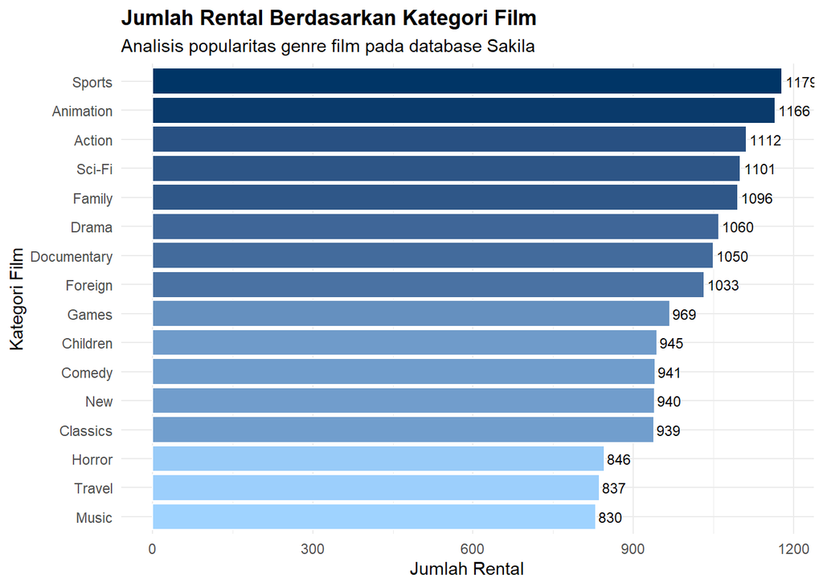

```r
ggplot(
  genre_rental,
  aes( x = reorder(category, total_rental),
       y = total_rental, fill = total_rental ) ) +
  geom_bar( stat = "identity", color = "white" ) +
  geom_text( aes(label = total_rental),
             hjust = -0.1, size = 3 ) +
  scale_fill_gradient( low = "#9FD3FF",
                      high = "#003566" ) +
  coord_flip() +
  labs( title = "Jumlah Rental Berdasarkan Kategori Film",
        subtitle = "Analisis popularitas genre film pada database Sakila",
        x = "Kategori Film",
        y = "Jumlah Rental" ) +
  theme_minimal() +
  theme( legend.position = "none", plot.title = element_text(face = "bold") )
```

## Interpretasi Data

Berdasarkan hasil analisis, terdapat perbedaan jumlah rental pada setiap kategori film. Genre dengan jumlah rental tertinggi menunjukkan bahwa kategori tersebut lebih diminati pelanggan dibandingkan kategori lainnya.

# Insight 2: TOP 10 Film Populer

## Deskripsi Insight

Insight kedua bertujuan untuk mengetahui film yang paling sering dirental oleh pelanggan. Analisis ini dapat menunjukkan film mana yang memiliki tingkat popularitas paling tinggi.

## Pengambilan Data

```r
query2 <- "select f.title as judul_film,
       count(r.rental_id) as total_rental
from rental r
join inventory i
on r.inventory_id = i.inventory_id
join film f
on i.film_id = f.film_id
group by f.title
order by total_rental desc
limit 10;"

top10_film <- dbGetQuery(con, query2)
top10_film$total_rental <- as.numeric(top10_film$total_rental)
top10_film
```

```
##             judul_film total_rental
## 1   BUCKET BROTHERHOOD           34
## 2     ROCKETEER MOTHER           33
## 3  RIDGEMONT SUBMARINE           32
## 4       GRIT CLOCKWORK           32
## 5        SCALAWAG DUCK           32
## 6       JUGGLER HARDLY           32
## 7       FORWARD TEMPLE           32
## 8         HOBBIT ALIEN           31
## 9         ROBBERS JOON           31
## 10           ZORRO ARK           31
```

## Analisis Data

Analisis dilakukan menggunakan fungsi `COUNT()` untuk menghitung jumlah transaksi rental pada setiap film, kemudian dipilih 10 film dengan jumlah rental tertinggi menggunakan `LIMIT 10`.

## Visualisasi Data

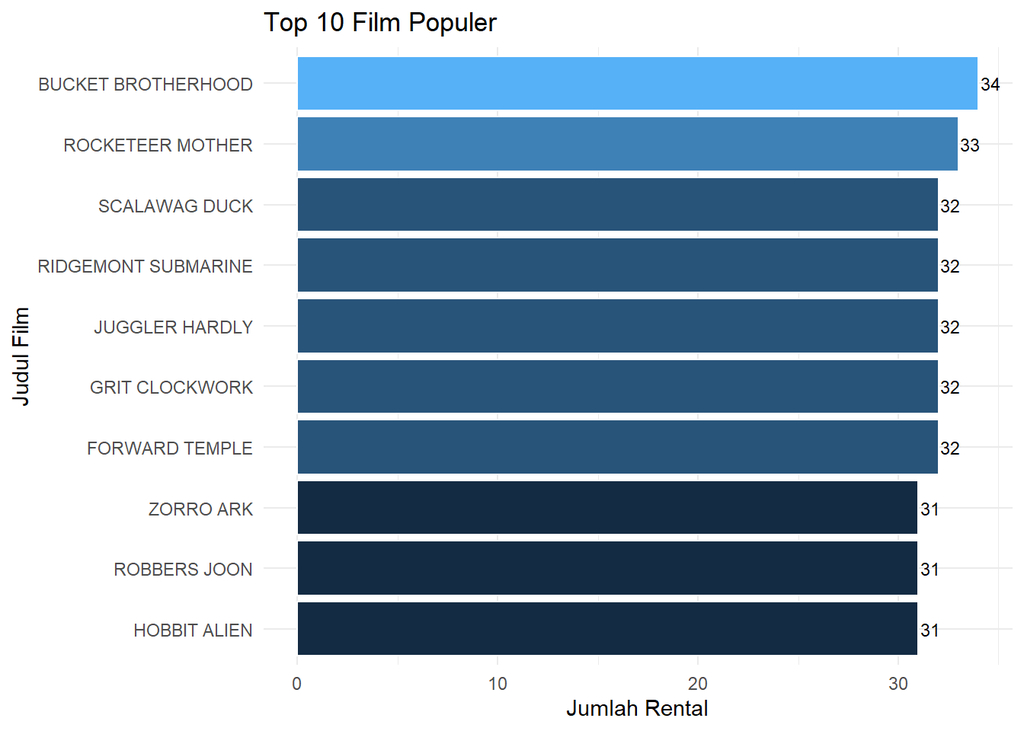

```r
ggplot( top10_film,
        aes( x = reorder(judul_film, total_rental),
             y = total_rental, fill = total_rental ) ) +
  geom_bar( stat = "identity", color = "white" ) +
  geom_text( aes(label = total_rental),
             hjust = -0.1, size = 3 ) + coord_flip() +
  theme_minimal() +
  labs( title = "Top 10 Film Populer",
        x = "Judul Film", y = "Jumlah Rental" ) +
  theme( legend.position = "none" )
```

# Kesimpulan

Berdasarkan analisis yang telah dilakukan terhadap database Sakila, diperoleh beberapa insight mengenai pola penyewaan film pada bisnis rental film. Genre film tertentu memiliki tingkat popularitas lebih tinggi dibandingkan genre lainnya. Selain itu, terdapat beberapa film yang memiliki jumlah rental tertinggi sehingga dapat dikategorikan sebagai film populer. Dengan adanya analisis ini, dapat menjadi pertimbangan untuk meningkatkan kualitas genre dan film yang populer. Selain itu, untuk genre dan film yang kurang diminati dapat dilakukan evaluasi untuk meningkatkan kualitas dan pendapatan dalam bisnis rental film.